# IML_Week_4_Assignment_Learner_template

### 5) Develop a model to predict whether a given car gets high or low gas mileage based on the `Auto` data set. Load the dataset:

```python
# BEGIN SOLUTION
#Load dataset
df = sm.datasets.get_rdataset('Auto', 'ISLR').data
print(sm.datasets.get_rdataset('Auto', 'ISLR').__doc__)
df.head(5)
# END SOLUTION
```

```
.. container::

   ==== ===============
   Auto R Documentation
   ==== ===============

   .. rubric:: Auto Data Set
      :name: Auto

   .. rubric:: Description
      :name: description

   Gas mileage, horsepower, and other information for 392 vehicles.

   .. rubric:: Usage
      :name: usage

   .. code:: R

      Auto

   .. rubric:: Format
      :name: format

   A data frame with 392 observations on the following 9 variables.

   ``mpg``
      miles per gallon

   ``cylinders``
      Number of cylinders between 4 and 8

   ``displacement``
      Engine displacement (cu. inches)

   ``horsepower``
      Engine horsepower

   ``weight``
      Vehicle weight (lbs.)
```

[output cut: 23 more lines]

```
   .. rubric:: References
      :name: references

   James, G., Witten, D., Hastie, T., and Tibshirani, R. (2013) *An
   Introduction to Statistical Learning with applications in R*,
   https://www.statlearning.com, Springer-Verlag, New York

   .. rubric:: Examples
      :name: examples

   .. code:: R

      pairs(Auto)
      attach(Auto)
      hist(mpg)
```

| rownames | mpg | cylinders | displacement | horsepower | weight | acceleration | year | origin | name |
| --- | --- | --- | --- | --- | --- | --- | --- | --- | --- |
| 1 | 18.0 | 8 | 307.0 | 130 | 3504 | 12.0 | 70 | 1 | chevrolet chevelle malibu |
| 2 | 15.0 | 8 | 350.0 | 165 | 3693 | 11.5 | 70 | 1 | buick skylark 320 |
| 3 | 18.0 | 8 | 318.0 | 150 | 3436 | 11.0 | 70 | 1 | plymouth satellite |
| 4 | 16.0 | 8 | 304.0 | 150 | 3433 | 12.0 | 70 | 1 | amc rebel sst |
| 5 | 17.0 | 8 | 302.0 | 140 | 3449 | 10.5 | 70 | 1 | ford torino |

```python
# BEGIN SOLUTION
df.describe(include='all')
# END SOLUTION
```

|  | mpg | cylinders | displacement | horsepower | weight | acceleration | year | origin | name |
| --- | --- | --- | --- | --- | --- | --- | --- | --- | --- |
| count | 392.000000 | 392.000000 | 392.000000 | 392.000000 | 392.000000 | 392.000000 | 392.000000 | 392.000000 | 392 |
| unique | NaN | NaN | NaN | NaN | NaN | NaN | NaN | NaN | 301 |
| top | NaN | NaN | NaN | NaN | NaN | NaN | NaN | NaN | amc matador |
| freq | NaN | NaN | NaN | NaN | NaN | NaN | NaN | NaN | 5 |
| mean | 23.445918 | 5.471939 | 194.411990 | 104.469388 | 2977.584184 | 15.541327 | 75.979592 | 1.576531 | NaN |
| std | 7.805007 | 1.705783 | 104.644004 | 38.491160 | 849.402560 | 2.758864 | 3.683737 | 0.805518 | NaN |
| min | 9.000000 | 3.000000 | 68.000000 | 46.000000 | 1613.000000 | 8.000000 | 70.000000 | 1.000000 | NaN |
| 25% | 17.000000 | 4.000000 | 105.000000 | 75.000000 | 2225.250000 | 13.775000 | 73.000000 | 1.000000 | NaN |
| 50% | 22.750000 | 4.000000 | 151.000000 | 93.500000 | 2803.500000 | 15.500000 | 76.000000 | 1.000000 | NaN |
| 75% | 29.000000 | 8.000000 | 275.750000 | 126.000000 | 3614.750000 | 17.025000 | 79.000000 | 2.000000 | NaN |
| max | 46.600000 | 8.000000 | 455.000000 | 230.000000 | 5140.000000 | 24.800000 | 82.000000 | 3.000000 | NaN |

```python
print("The Number of missing values:")
df.isnull().sum()
```

```
The Number of missing values:
```

```
mpg             0
cylinders       0
displacement    0
horsepower      0
weight          0
acceleration    0
year            0
origin          0
name            0
dtype: int64
```

```python
print(df.nunique())
print("Cylinders : ", df["cylinders"].unique())
print("origin : ", df["origin"].unique())
print("year : ", df["year"].unique())
```

```
mpg             127
cylinders         5
displacement     81
horsepower       93
weight          346
acceleration     95
year             13
origin            3
name            301
dtype: int64
Cylinders :  [8 4 6 3 5]
origin :  [1 3 2]
year :  [70 71 72 73 74 75 76 77 78 79 80 81 82]
```

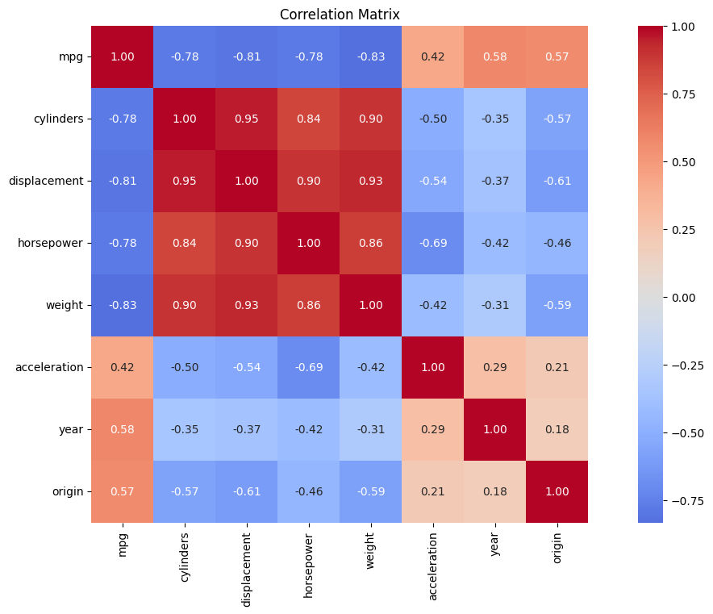

```python
# BEGIN SOLUTION

correlation_matrix = df.drop(columns=["name"]).corr()
plt.figure(figsize=(16, 8))
sns.heatmap(correlation_matrix, annot=True, cmap='coolwarm', fmt='.2f', square=True, center=0.0)
plt.title('Correlation Matrix')
plt.show()
# END SOLUTION
```

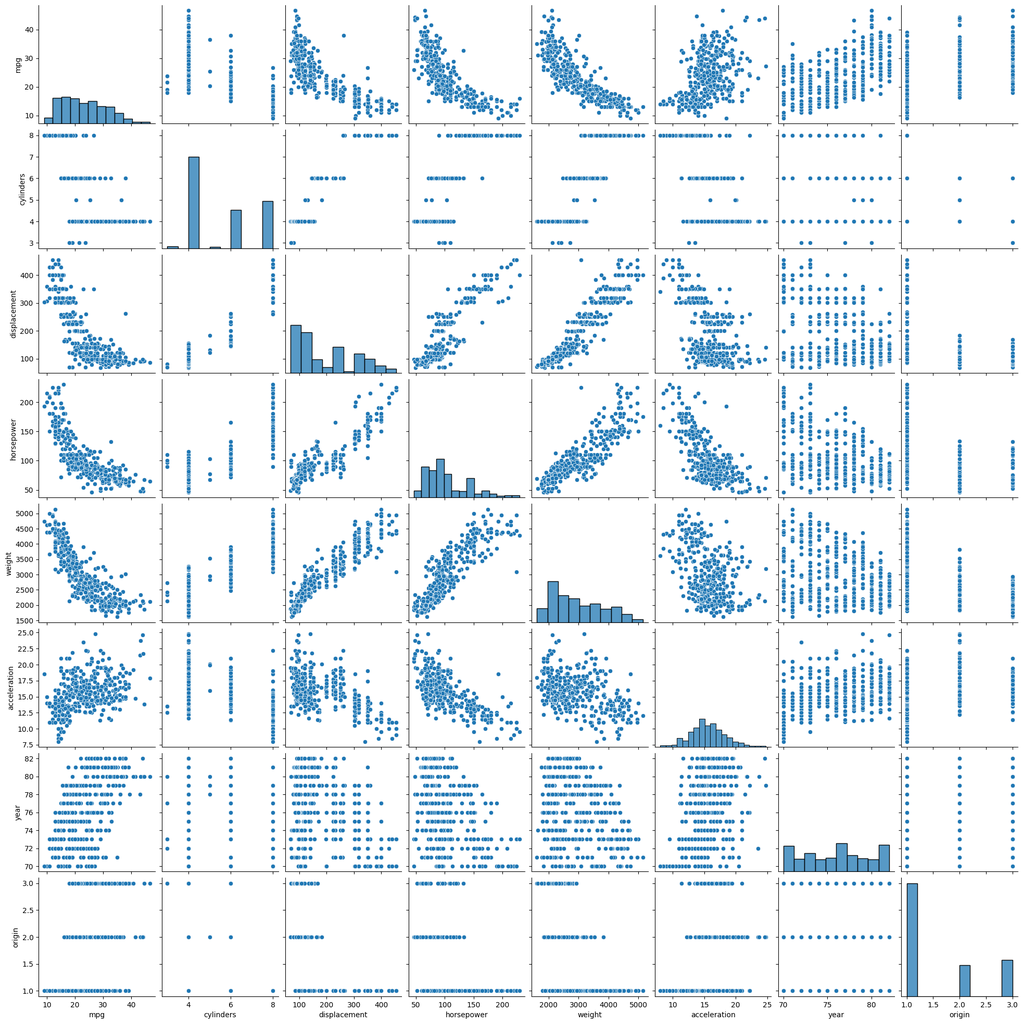

```python
sns.pairplot(data=df)
```

a) Create a binary variable, `mpg01`, that contains a `1` if `mpg` contains a value above its median, and a `0` if `mpg` contains a value below its median.Note : you may find it helpful to use the `pd.DataFrame()` function to create a single data set containing both `mpg01` and the other `Auto` variables.

Link to median(): https://pandas.pydata.org/docs/reference/api/pandas.DataFrame.median.html

```python
# BEGIN SOLUTION
median_mpg = df['mpg'].median()
df['mpg01'] = (df['mpg'] > median_mpg).astype(int)
df
# END SOLUTION
```

| rownames | mpg | cylinders | displacement | horsepower | weight | acceleration | year | origin | name | mpg01 |
| --- | --- | --- | --- | --- | --- | --- | --- | --- | --- | --- |
| 1 | 18.0 | 8 | 307.0 | 130 | 3504 | 12.0 | 70 | 1 | chevrolet chevelle malibu | 0 |
| 2 | 15.0 | 8 | 350.0 | 165 | 3693 | 11.5 | 70 | 1 | buick skylark 320 | 0 |
| 3 | 18.0 | 8 | 318.0 | 150 | 3436 | 11.0 | 70 | 1 | plymouth satellite | 0 |
| 4 | 16.0 | 8 | 304.0 | 150 | 3433 | 12.0 | 70 | 1 | amc rebel sst | 0 |
| 5 | 17.0 | 8 | 302.0 | 140 | 3449 | 10.5 | 70 | 1 | ford torino | 0 |
| ... | ... | ... | ... | ... | ... | ... | ... | ... | ... | ... |
| 393 | 27.0 | 4 | 140.0 | 86 | 2790 | 15.6 | 82 | 1 | ford mustang gl | 1 |
| 394 | 44.0 | 4 | 97.0 | 52 | 2130 | 24.6 | 82 | 2 | vw pickup | 1 |
| 395 | 32.0 | 4 | 135.0 | 84 | 2295 | 11.6 | 82 | 1 | dodge rampage | 1 |
| 396 | 28.0 | 4 | 120.0 | 79 | 2625 | 18.6 | 82 | 1 | ford ranger | 1 |
| 397 | 31.0 | 4 | 119.0 | 82 | 2720 | 19.4 | 82 | 1 | chevy s-10 | 1 |

392 rows × 10 columns